# Timings, near-field calculations

22 October, 2021

## Objective

This example considers the scaling of computational time with respect to key parameters:

- number of particles
- number of multipoles
- number of incidence angles
- solution scheme

The number of wavelengths simply scales the computation time for all other parameters, as everything needs to be re-calculated for each wavelength (assuming negligible input-output time, compared to the calculations).

## Parameters

| Npart | Nmax | Ninc | OA | scheme |
| --- | --- | --- | --- | --- |
| 1 | 8 | 1 | True | 0 |
| 1 | 8 | 1 | True | 1 |
| 1 | 8 | 1 | True | 2 |
| 1 | 8 | 1 | True | 3 |
| 1 | 16 | 1 | True | 0 |
| 1 | 16 | 1 | True | 1 |
| 1 | 16 | 1 | True | 2 |
| 1 | 16 | 1 | True | 3 |
| 2 | 8 | 1 | True | 0 |
| 2 | 8 | 1 | True | 1 |

[output cut: 134 more lines]

The structure consists of a helix of gold spheres, with varying number of particles.

```
Rows: 11,372
Columns: 9
$ Npart   <dbl> 1, 1, 1, 1, 1, 1, 1, 1, 1, 1, 1, 1, 1, 1, 1, 1, 1, 1, 1, 1, 1,…
$ Nmax    <dbl> 8, 8, 8, 8, 8, 8, 8, 8, 8, 8, 8, 8, 8, 8, 8, 8, 8, 8, 8, 8, 8,…
$ Ninc    <dbl> 1, 1, 1, 1, 1, 1, 1, 1, 1, 1, 1, 1, 1, 1, 1, 1, 1, 1, 1, 1, 1,…
$ OA      <lgl> TRUE, TRUE, TRUE, TRUE, TRUE, TRUE, TRUE, TRUE, TRUE, TRUE, TR…
$ scheme  <int> 0, 0, 0, 0, 0, 0, 1, 1, 1, 1, 1, 1, 1, 1, 2, 2, 2, 2, 2, 2, 2,…
$ log     <chr> "1", "1", "1", "1", "1", "1", "2", "2", "2", "2", "2", "2", "2…
$ routine <chr> "solLinSys", "solve", "calcField", "calcLDOC", "mapNF", "terms…
$ cpu     <dbl> NA, 8.657e-02, 2.372e-03, 5.500e-05, 4.059e-03, 2.396e-01, NA,…
$ total   <dbl> 0.006, 0.007, 0.001, 0.000, 0.001, 0.021, 0.005, 0.006, NA, NA…
```

## Detailed timings (subroutines)

### Varying number of particles

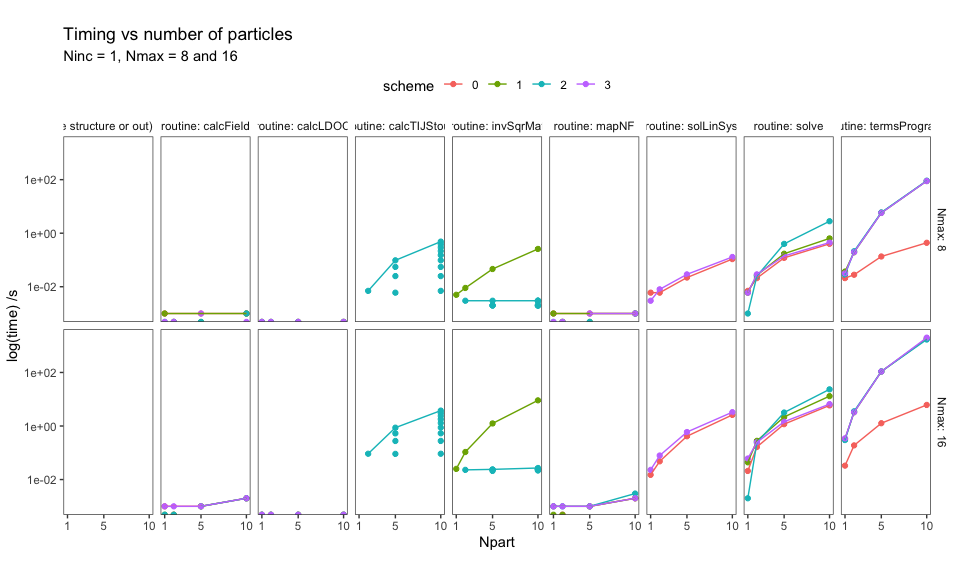

We can make some general remarks,

- The Stout Scheme (2) solves recursively the multiple scattering problem, starting with a dimer, and adding one particle at a time. This is evident in the routine `calcTIJStout` which increases in time, and in the routine `invSqrMat` which shows a dramatic improvement over `Scheme = 1` (previous version by the same authors)
- Mackwoski’s Scheme (3) is very performant across the board; in fact it is about as fast as solving the original coupled-system without seeking the collective T-matrix, with the advantage that it also calculates orientation-averaged properties

### Varying maximum multipole order

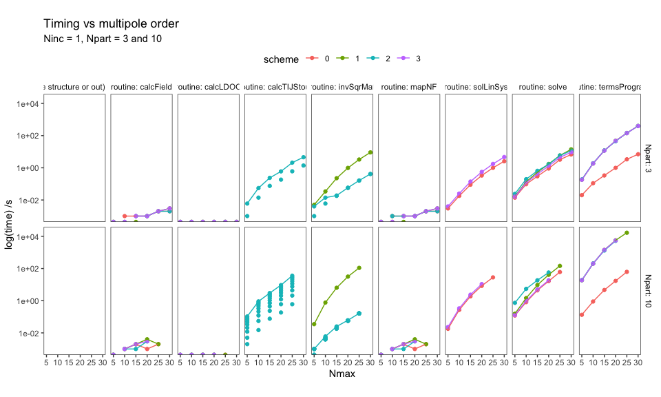

The computational cost scales similarly for all Schemes and subroutines with respect to maximum multipolar order.

### Varying number of incidence directions

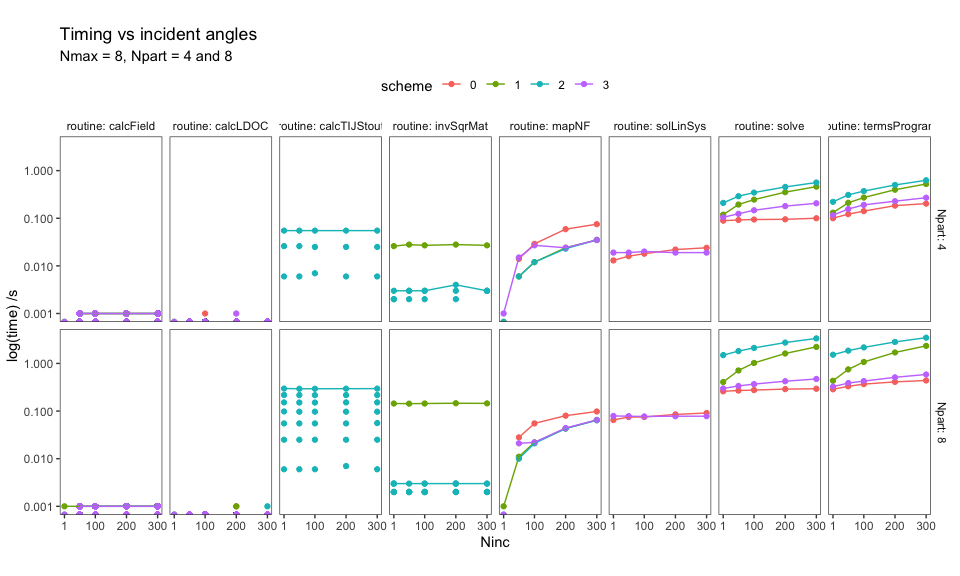

Solving a linear system for multiple incidences (right hand side) differs between Scheme 0 (direct solve) and the other schemes (which seek a collective T-matrix). This is visible in routine `solLinSys`, which is constant for Scheme 3 (and similarly for Stout’s schemes 1 and 2).

## Total timings

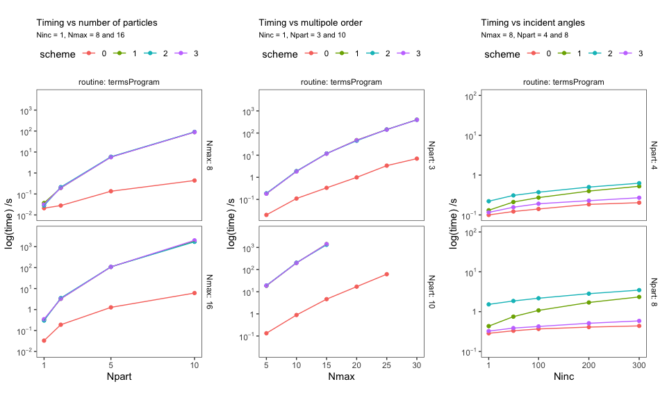

*Last run: 22 October, 2021*